# SNV selection intensity

Vincent L. Cannataro

This document describes our pipeline to estimate the selection intensity for single nucleotide variants (SNVs) in whole-exome sequencing data.

Here, as an example, we estimate the selection intensity of SNVs in lung adenocarcinoma (LUAD) data.

# Import and preprocess the data

The data for this pipeline needs to be in MAF format, hg19 coordinates, and have the following headers:

- Hugo_Symbol
- Chromosome
- Start_Position
- Variant_Type
- Tumor_Sample_Barcode

## Import the NCI data and any non-NCI data

Obtain the NCI data from https://portal.gdc.cancer.gov/ and store it within the `input_data/` folder. The `YG.data` dataset may be found along with Cannataro *et al.* (2017)[^1]

```r
# import the LUAD data from NCI
# UUID: 81ccaef3-4550-494d-882c-895fb5a3de3b
NCI.data.38 <- read.csv(file = "input_data/TCGA.LUAD.mutect.81ccaef3-4550-494d-882c-895fb5a3de3b.DR-7.0.somatic.maf",
                        header = T,
                        skip = 5,
                        sep = "\t",
                        stringsAsFactors = F)

# import data from a non-NCI source
YG.data <- read.csv(file = "input_data/YG_LUAD_data.txt",
                    header = T,
                    sep = "\t",
                    stringsAsFactors = F)
```

## Preprocess the data

```r
# First, need to source functions

# This downloads and unzips the file hg38ToHg19.over.chain.gz from
# http://hgdownload.cse.ucsc.edu/gbdb/hg38/liftOver/  (if it is not already there)
# and then loads in a function that does the converting
source("R/hg39_to_hg19_converter.R")

source("R/unique_tumor_addition.R") # Adds tumor name to dataframe
source("R/flip_function.R") # Finds nucleotide complement
source("R/DNP_remover.R") # removes possible DNP, and recurrent (non-primary) tumors from TCGA data
source("R/tumor_allele_adder.R") # adds column with the tumor allele

## Then, use the functions.
NCI.data.19 <- hg38.to.hg19.converter(chain='input_data/hg38Tohg19.chain',hg38_maf=NCI.data.38)
NCI.data.19 <- DNP.remover(MAF = NCI.data.19)
NCI.data.19$Tumor_Seq_Allele2 <- toupper(NCI.data.19$Tumor_Seq_Allele2)
NCI.data.19$Reference_Allele <- toupper(NCI.data.19$Reference_Allele)
NCI.data.19 <- tumor.allele.adder(MAF = NCI.data.19)

#Save the NCI dataframe
save(NCI.data.19, file = "output_data/NCI_data_LUAD.RData")
```

If necessary, combine the NCI data with any other dataset along common headers, add custom headers again.

```r
source("R/merging_NCI_and_local_MAF_files.R")


MAF_for_analysis <- merging_TCGA_and_local_MAFdata_function(NCI_data = NCI.data.19,
                                                            Local_data = YG.data)

MAF_for_analysis <- unique.tumor.addition.function(MAF.file = MAF_for_analysis,non.TCGA.characters.to.keep = 'all',figures=F)
MAF_for_analysis <- DNP.remover(MAF = MAF_for_analysis)
MAF_for_analysis$Tumor_Seq_Allele2 <- toupper(MAF_for_analysis$Tumor_Seq_Allele2)
MAF_for_analysis$Reference_Allele <- toupper(MAF_for_analysis$Reference_Allele)
MAF_for_analysis <- tumor.allele.adder(MAF = MAF_for_analysis)

save(MAF_for_analysis, file = "output_data/MAF_for_analysis_LUAD.RData")
```

Match the gene names in the `Hugo_Symbol` column in the MAF file and `geneName` column in the isoform file with gene names in the `MutSigCV` covariates file. The isoform file was downloaded from the [genome.ucsc.edu](https://genome.ucsc.edu/cgi-bin/hgTables) table browser, specifying `group: Genes and Gene Predictions`, `track: RefSeq Genes`, and `table: refFlat` in the human hg19 genome. Gene expression data are median values from lung data sets in `The Cancer Cell Line Encyclopedia`[^2] matched to the genes and data in the [MutSigCV covariate input file](http://software.broadinstitute.org/cancer/software/genepattern/modules/docs/MutSigCV) and saved as `input_data/LUNG_expression.txt`.

# Calculate mutation rate with MutSigCV

Steps to calculate mutation rates with MutSigCV:

1. Agree to the MutSigCV license and download MutSigCV 1.41 from http://archive.broadinstitute.org/cancer/cga/mutsig_download.
2. Download MutSigCV 1.41 reference files from http://archive.broadinstitute.org/cancer/cga/mutsig_run#reference_files. Save files to the MutSigCV folder and unzip.
3. Add contents of input_data/to_add_MutSigCV.txt to line 953 of MutSigCV.m.
4. Run with `input_data/LUNG_expression.txt` as the covariate file and `output_data/MAF_for_analysis_LUAD.txt` as the mutation file

Outputs `*.gene_rates.txt` and `*.overall_rates.txt`, which we use to calculate mutation rate within genes

# Calculate the trinucleotide mutation profile of this tissue

Use the `deconstructSigs` package to calculate the average trinucleotide context among tumors with over 50 SNV (as per [^3]).

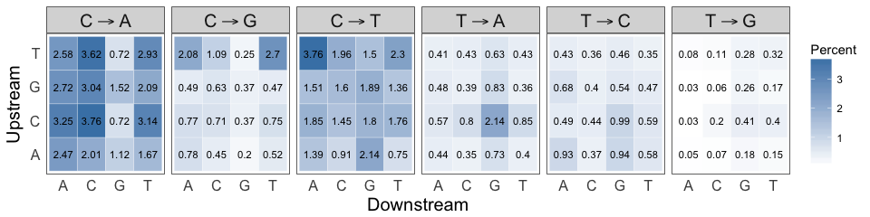

# Calculating selection intensity

```r
source("R/selection_intensity_calc.R")
source("R/flip_function.R")
source("R/lambda_calculation.R")

load("output_data/trinuc_data_LUAD.RData")
load("output_data/Isoforms_LUAD.RData")
load("output_data/MAF_for_analysis_LUAD.RData")

selection.output <- selection.intensity.calculation.function(genes_for_analysis = c("KRAS","TP53","APC","EGFR"),
                                                                 MAF_for_analysis = MAF_for_analysis,
                                                                 this.substitution = c("this_is_not_a_real_gene",34,"T"),
                                                                 trinuc.mutation_data = trinuc.mutation_data.df,
                                                                 LabReference =  isoforms,
                                                                 translations =  read.csv(file = "input_data/translations.csv",header = T,stringsAsFactors = F),
                                                                 mut_rates = read.csv(file="MutSigCV/MutSigCV_1.41/gene_rates.txt",header = T,stringsAsFactors = F,sep="\t"),
                                                                 low.mut = read.csv(file="MutSigCV/MutSigCV_1.41/overall_rates.txt",header = F,stringsAsFactors = F,sep="\t"),tumor.number = length(unique(MAF_for_analysis$Unique_patient_identifier)),mutsig_siggenes = read.csv(file="MutSigCV/MutSigCV_1.41/mutsig_output/.sig_genes.txt",header = T,stringsAsFactors = F,sep="\t"))


save(selection.output,file = "output_data/selection_intensity_output.RData")
```

[^1]: Cannataro, V. L., Gaffney, S. G., Stender, C., Zhao, Z., Philips, M., Greenstein, A. E., Townsend, J. P. (2017) “Heterogeneity and mutation in KRAS and associated oncogenes: evaluating the potential for the evolution of resistance to targeting of KRAS G12C” Oncogene, in press
[^2]: Barretina, Jordi, Giordano Caponigro, Nicolas Stransky, Kavitha Venkatesan, Adam A. Margolin, Sungjoon Kim, Christopher J. Wilson, et al. 2012. “The Cancer Cell Line Encyclopedia Enables Predictive Modelling of Anticancer Drug Sensitivity.” Nature 483 (7391): 603–7.
[^3]: Rosenthal, Rachel, Nicholas McGranahan, Javier Herrero, Barry S. Taylor, and Charles Swanton. 2016. “DeconstructSigs: Delineating Mutational Processes in Single Tumors Distinguishes DNA Repair Deficiencies and Patterns of Carcinoma Evolution.” Genome Biology 17 (February): 31.